# Introduction à la modélisation statistique bayésienne

## Plan

- Rappels et objectifs
- Définition du modèle
- La distribution postérieure
- **Utilisation du modèle**
  - **Estimation des tendances centrales**
  - **Highest density interval (HDI)**
  - **ROPE**
  - **Bayes factor**
  - **BIC**

### Utilisation du modèle

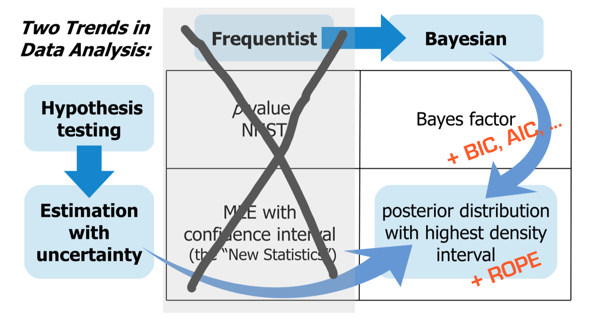

### Utilisation du modèle

### ESTIMATION DE LA TENDANCE CENTRALE

**DESCRIPTION** : A partir d'un échantillon d'une distribution postérieure, on peut calculer la moyenne, le mode et la médiane

```r
library(rethinking)
chainmode( samples , adj=0.01 ) # pour le mode ou MAP
mean( samples )                 # pour la moyenne
median( samples )               # pour la médiane
```

Exemple pour un prior uniforme, et 10 lancers successifs et 3 Faces

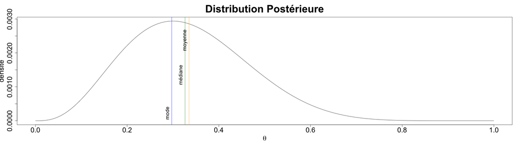

### Utilisation du modèle

### ESTIMATION DE LA TENDANCE CENTRALE - Cas “pathologique”“

**DESCRIPTION** : A partir d'un échantillon d'une distribution postérieure, on peut calculer la moyenne, le mode et la médiane

```r
library(rethinking)
chainmode( samples , adj=0.01 ) # pour le mode ou MAP
mean( samples )                 # pour la moyenne
median( samples )               # pour la médiane
```

Exemple pour un prior uniforme, et 3 lancers successifs et 3 Faces

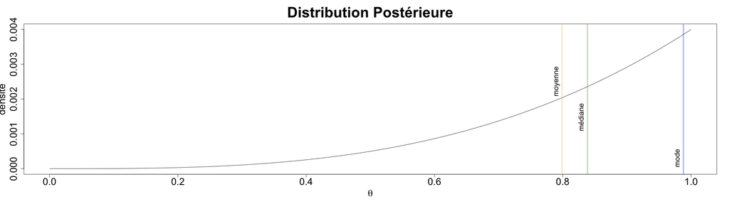

### Utilisation du modèle

### ESTIMATION DE LA TENDANCE CENTRALE

**DÉCISION** : Comment chosir la valeur qui résume le “mieux” la distribution postérieure  
Utiliser des fonctions d'**espérance de gain** ou, ce qui revient au même, de **perte attendue**

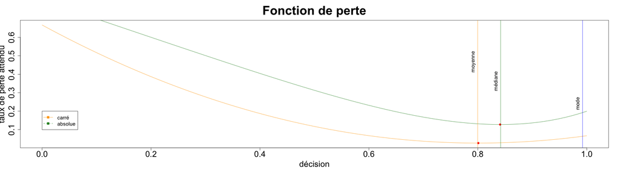

```r
# pour la moyenne
sapply( p_grid , function(d) sum( posterior*( d - p_grid )^2 ) )
# pour la médiane
sapply( p_grid , function(d) sum( posterior*abs( d - p_grid ) ) )
```

### Utilisation du modèle

### HIGHEST POSTERIOR DENSITY INTERVAL (HPDI)

- Le HPDI indique les valeurs du paramètre qui sont le plus crédibles
- Plus le HPDI est étroit et plus le degré de certitude est élevé
- La largeur du HPDI diminue avec l'augmentation du nombre de mesures
- Le pourcentage de la masse de probabilité n'est pas nécessairement 95

> Définition: les valeurs du paramètre x contenues dans le HPDI 89% sont telles que \( p(x)>W \) et

> \[ \int_{x:p(x)>W} p(x) \, \mathrm dx=0.89 \]

### Utilisation du modèle

### HIGHEST POSTERIOR DENSITY INTERVAL (HPDI)

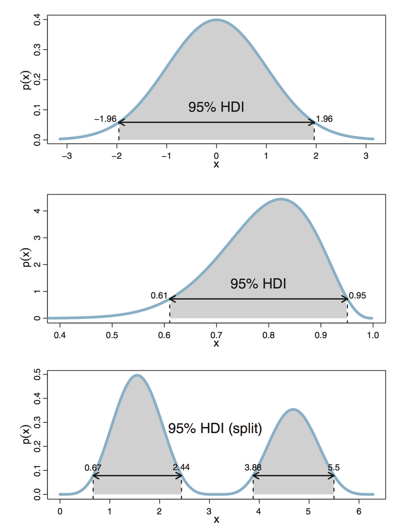

### Utilisation du modèle

### HIGHEST POSTERIOR DENSITY INTERVAL (HPDI)

**En pratique - Package BEST**

```r
library(coda)
library(BEST)
set.seed(1234567)
iterMax = 10000
p_grid  = seq( from=0 , to=1 , length.out=iterMax )
pTheta  = dbeta( p_grid, 3, 10)
massVec = pTheta/sum(pTheta)
samples = sample( p_grid , size=1e4 , replace=TRUE , prob=pTheta )

#plotPost(samples, credMass = 0.85)
hdi( samples , credMass = 0.89 )
```

```
     lower      upper
0.05280528 0.39613961
attr(,"credMass")
[1] 0.89
```

### Utilisation du modèle

### HIGHEST POSTERIOR DENSITY INTERVAL (HPDI)

**En pratique - Package BEST**

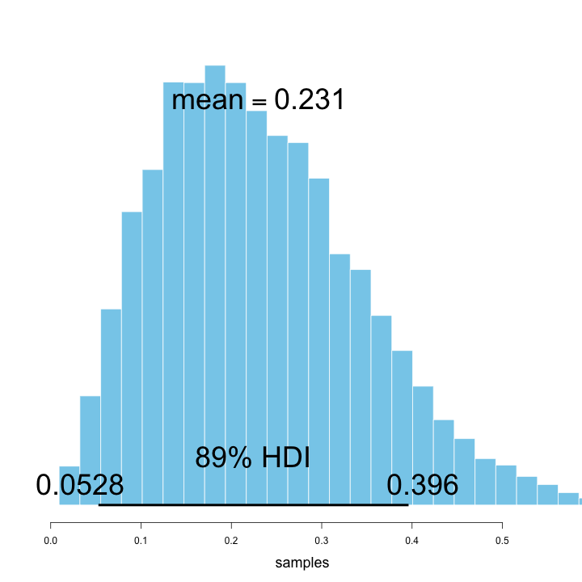

```r
library(BEST)
library(coda)
set.seed(1234567)
iterMax = 10000
p_grid  = seq( from=0 , to=1 , length.out=iterMax )
pTheta  = dbeta( p_grid, 3, 10)
massVec = pTheta/sum(pTheta)
samples = sample( p_grid , size=1e4 , replace=TRUE , prob=pTheta )

plotPost(samples,  credMass = 0.89, cex = 3)
```

### Utilisation du modèle

### HIGHEST POSTERIOR DENSITY INTERVAL (HPDI)

**En pratique - Package rethinking**

```r
library(rethinking)
set.seed(1234567)
iterMax = 10000
p_grid  = seq( from=0 , to=1 , length.out=iterMax )
pTheta  = dbeta( p_grid, 3, 10)
massVec = pTheta / sum(pTheta)
samples = sample( p_grid , size = 1e4 , replace = TRUE , prob = pTheta )

# utilise le package CODA pour calculer HPDI
HPDI( samples, prob = 0.89)
```

```
     |0.89      0.89|
0.05280528 0.39613961
```

### Utilisation du modèle

### ROPE - Region Of Practical Equivalence

**On l'utilise pour “tester une hypothèse”**

- Pour tester H0, la décision est basée sur le HPDI et sur le ROPE
- La valeur du paramètre (ici 0) est rejetée si son ROPE exclus le 95% HPDI
- La valeur du paramètre (ici 0) est accepté si le 95% HDI est entièrement inclus dans son ROPE
- Si le HDI et le ROPE se chevauchent on ne peut rien dire…

### Utilisation du modèle

### ROPE - Region Of Practical Equivalence

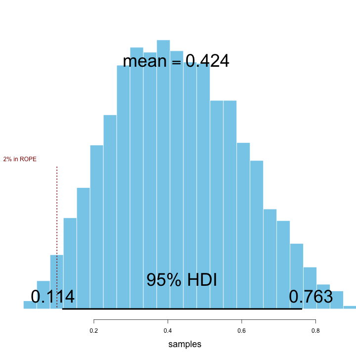

```r
library(BEST)
library(coda)
set.seed(1234567)
terMax = 10000
p_grid  = seq( from=0 , to=1 , length.out=iterMax )
pTheta  = dbeta( seq(0, 1, length=iterMax), 3, 4)
massVec = pTheta/sum(pTheta)
samples = sample( p_grid , size=1e4 , replace=TRUE , prob=pTheta )

plotPost(samples,  ROPE=c(-0.1,0.1), cex = 3)
```

### Utilisation du modèle

### COMPARAISON DE MODÈLES - Principes

On considère une pièce. On la lance 200 fois et on obtient 115 *Faces*.

> QUESTION : La pièce est-elle biaisée?

Nous construisons deux modèles et essayons de savoir lequel est le plus probable

> \[ \begin{eqnarray*} \left\{ \begin{array}{ll} M_0~:~X \sim \mathcal{B}(N,0.5) & \quad \text{la pièce n'est pas biaisée}\\ M_1~:~X \sim \mathcal{B}(N,\theta) & \quad \text{la pièce est biaisée} \end{array}\right. \end{eqnarray*} \]

### Utilisation du modèle

### COMPARAISON DE MODÈLES - Bayes Factor

> Le facteur de Bayes fait le rapport des vraissemblances des deux modèles.

> \[ \frac{P(M_0~|~D)}{P(M_1~|~D)}=\color{orangered}{\frac{P(D~|~M_0)}{P(D~|~M_1)}}~\frac{P(M_0)}{P(M_1)} \]

Dans cet exemple, le calcul de \( P(D~|~M_0) \) est facile

\( P(D~|~M_0) = C_{200}^{115}~(0.5)^{115}~(1-0.5)^{(200-115)} = 0.005955 \)

### Utilisation du modèle

### COMPARAISON DE MODÈLES - Bayes Factor

> Le facteur de Bayes fait le rapport des vraissemblances des deux modèles.

> \[ \frac{P(M_0~|~D)}{P(M_1~|~D)}=\frac{P(D~|~M_0)}{\color{orangered}{P(D~|~M_1)}}~\frac{P(M_0)}{P(M_1)} \]

Pour calculer de \( P(D~|~M_1) \), c'est plus compliqué : \( \color{orangered}{~~~\textbf{On ne connait pas }\theta} \)

### Utilisation du modèle

### COMPARAISON DE MODÈLES - Bayes Factor

> Le facteur de Bayes fait le rapport des vraissemblances des deux modèles.

> \[ \frac{P(M_0~|~D)}{P(M_1~|~D)}=\color{orangered}{\frac{P(D~|~M_0)}{P(D~|~M_1)}}~\frac{P(M_0)}{P(M_1)} \]

Dans l'exemple,

> \[ B_{01} = \frac{P(M_0~|~D)}{P(M_1~|~D)} = \frac{0.005955}{0.005} = 1.1971 \]

Le rapport de probabilités a augmenté de 20% après avoir pris connaissance des données.  
La balance penche ici en faveur du modèle nul, **\( B_{01} > 1 \)**

### Utilisation du modèle

### COMPARAISON DE MODÈLES - Autre exemple

**BIC critère d’information bayésien**

La vraissemblance du modèle pas toujours calculable : \[ P(D~|~M)=\int_{\theta} P(D~|~M, \theta) \, \mathrm d\theta \]

> Calcul d'une valeur approchée \[ ln(P(D~|~\theta)) \approx ln(L(\widehat{\theta})) - \frac{t}{2}~ln(N) \]

> avec \( L(\widehat{\theta}) \) le maximum de vraissemblance  
> \( t \) le nombre de paramètres  
> \( N \) le nombre d'observations

### Utilisation du modèle

### MODEL CHECKING

**Les deux rôles de la fonction de vraissemblance**

- C'est une fonction de \( \theta \) pour le calcul de la distribution postérieure : \( L(\theta~|~z~N) \)
- Lorsque \( \theta \) est fixé, c'est une distribution de probablilité : \( P(z~|~\theta~N)=\theta^z~(1-\theta)^{(N-z)} \)

> On peut utiliser cette distribution de probabilité pour générer des données

```r
w <- rbinom(n = 10e4, size = 9, prob = 0.6)
```

### Utilisation du modèle

### MODEL CHECKING

**Deux sources d'incertitude dans ces prédictions**

- Incertitude lié à la valeur de \( p \) (évidemment !)  
  -> Chaque valeur apparaît avec une probabilité \( p \)
- Incertitude sur la valeur de \( p \) elle-même  
  -> Pour chaque valeur de \( p \) on peut calculer une distribution implicite

```r
w <- rbinom(n = 10e4, size = 9, prob = samples)
```

### Utilisation du modèle

### MODEL CHECKING

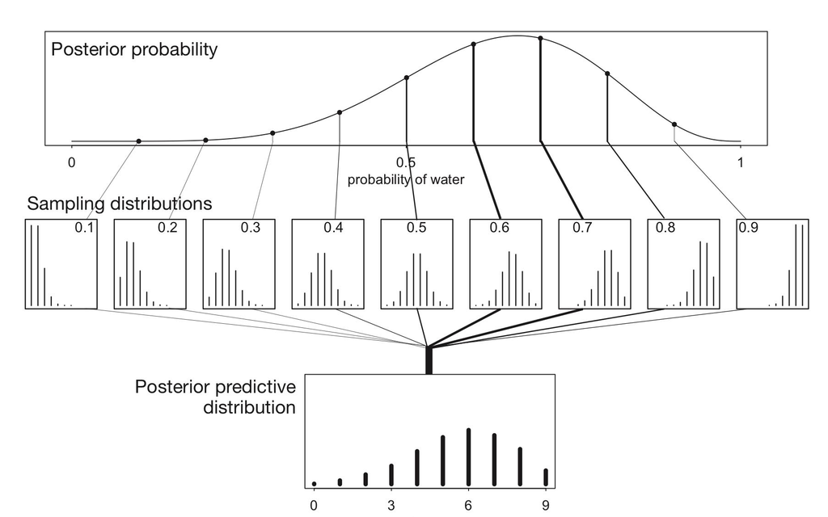